# Final Project

Ashley Wimbish

Data Science for Biologists, Spring 2024

# **Section 1: Project Introduction**

> “Tiger got to hunt, bird got to fly; Man got to sit and wonder ‘why, why, why?’ Tiger got to sleep, bird got to land; Man got to tell himself he understand.” -Kurt Vonnegut

## A Hypothesis is a Liability

In the early 1600’s the discovery of sunspots struck the European world of astronomy. Sunspots had been sparsely documented earlier by astronomers in China and Greece, but, in the West, it was believed that the celestial sphere was unique and unchanging. The combination of this belief and difficulty visualizing the sun left observations of sunspots ignored for hundreds of years. In a literature review, various instances of data/observation dependent analyses were evaluated to assess the current stance in biostatistics and scientific fields.

In their paper, [“A hypothesis is a liability”](https://doi.org/10.1186/s13059-020-02133-w), Yanai and Lercher argue that hypotheses come with a hidden cost. Our minds focus on the specific hypothesis we want to disprove, preventing us from finding new ideas in data. In the paper, subjects of their experiment were given a data set to analyze. Some participants had specific hypotheses to test while others were asked to explore the data. However, in the data was an important pattern, a scatterplot of the data revealed the picture of a gorilla. They found that people with a specific hypothesis to test were *less* likely to find this pattern in the data. This idea is similar to another in the Philosophy of Science called theory-ladenness of observation. Similarly, Norwood Russell Hanson argued that astronomers Kepler and Brahe, opposing in theory, literally saw different things at dawn. Their different theories skewed their perception of the same event in favor of their hypothesis. Interestingly, even as our observations become more verifiable, this idea persists in hypotheses. These instances present a defense for exploratory/post-hoc analyses and paradox within [the hypothetico-deductive model of science](https://journals.lww.com/academicmedicine/fulltext/2020/05000/the_positivism_paradigm_of_research.16.aspx).

The absence of hypotheses in exploratory analyses allows a full view of the patterns in observations/data beyond biases and assumptions. I agree with the conclusions of Yanai and Lercher, especially after performing my own data analysis project. Dozens of tables and plots did not make it into this final document because there were more insightful patterns I did not initially think about. I was not asking the right questions. Exploratory data visualization is important to reveal patterns for any further statistical testing. However questions remain on the subject of post hoc analyses. [Studies, even “failed” ones that did not reach their intended endpoint, have valuable information that could inform future studies](https://www.als.net/news/what-is-post-hoc-analysis-in-a-clinical-trial/). It a costly to conduct research and collect new data. Some post-hoc analyses would allow us to aggregate large sample sizes from previous studies. These samples are more likely to be normally distributed regardless of the population’s distribution (Figure 1). These distributions are remarkably helpful because they are a well studied predictable tool for statistical modeling. Additionally, some post-hoc tests like the Tukey and Scheffe test are standard within introductory statistics. They are used as an alternative to running multiple significance tests when further comparison is needed.

### False Positive Rates and Fishing

In stark contrast, post-hoc analyses are also commonly criticized for their potential for fishing expeditions or p-hacking, the intentional repeated adjustment of data processing and analysis until the desired test statistic is reached. Multiple significance tests generate large false positive rates by a principle from probability. The probability of an outcome is greater, more likely to occur at least once, when it is tested multiple times. The same holds true for the probability of a false positive. Bland and Altman offer a good example in their paper [“Multiple significance tests: the Bonferroni method”](https://www.ncbi.nlm.nih.gov/pmc/articles/PMC2548561/pdf/bmj00576-0038.pdf). At the standard 0.05 significance level, we except 1 in 20 cases to produce a positive result by chance. If we conduct 20 independent tests, that increases the probability that at least one is falsely positive to 64% rather than the 5% that would be reported. Resulting in, a dramatically understated false positive rate, and thus increasing the potential for false positive results despite reported significance levels. Intuitively this makes sense, there is a huge degree of freedom a researcher can take in analysis of post-hoc data.

However, in their paper “The garden of forking paths: Why multiple comparisons can be a problem, even when there is no “fishing expedition” or “p-hacking” and the research hypothesis was posited ahead of time” Gelman and Loken show that even with the best intentions a single scientific hypothesis can be interpreted as multiple statistical hypotheses adding a new data-dependent variable to the analysis in the form of researcher degrees of freedom. Researcher degrees of freedom are choices in data collection, analysis and reporting made by the researcher. In [“False-Positive Psychology: Undisclosed Flexibility in Data Collection and Analysis Allows Presenting Anything as Significant”](https://journals.sagepub.com/doi/10.1177/0956797611417632), Simmons and colleagues, through stimulated analyses, found that certain combinations of researcher degrees of freedom can produce false positive rates up to 80%. The same issues of repeated adjustments in sub-grouping, sample size, and dependent variables exist in standard analyses. So, how do we proceed when the hypothesis is a function of the data it questions? Simmons and others critique common solutions researchers are drawn to, including a few I had thought of as alternatives, such as transparency in materials and data, bayesian statistics, and correcting p values. They ultimately land on a set of rigorous guidelines for researchers and reviewers to increase transparency.

### Report Summary and Conclusion

In brief, much consideration must be taken when performing post-hoc analyses. Perhaps exploratory and post-hoc studies exist solely to generate new hypotheses and find interesting patterns unburdened by the narrowed scope of theory. Or, possibly, as we develop our statistical knowledge, we will be able to better mediate researcher degrees of freedom and issues with multiple significance tests. Statistics is a vital component of scientific research. Scientific research is built on and should reward questioning data and generating new hypotheses, not weaken results and credibility. The challenge lies in connecting that work but to rigorous and decisive mathematics. The rigor of a study is only as good as its statistics.

The following report (Section 2) is my exploration and post-hoc analysis of a data set published by The California Department of Public Health from 22 years of disease records. Further consideration is needed to present relevant epidemiological findings. It demonstrates many skills I gained from participating in research, independent learning, and Data Science for Biologists at Rowan University designed by [Dr. Stephanie Spielman](https://github.com/sjspielman) and adapted by [Dr. Sara Wright](https://csm.rowan.edu/departments/bbs/facultystaff/bbs_full_part/wright-sara.html).

## Figure 1

Each plot consists of 100 means of random numbers from different sample sizes (2,10, and 50). All values were taken from a uniform distribution.

### Sample Size of 2

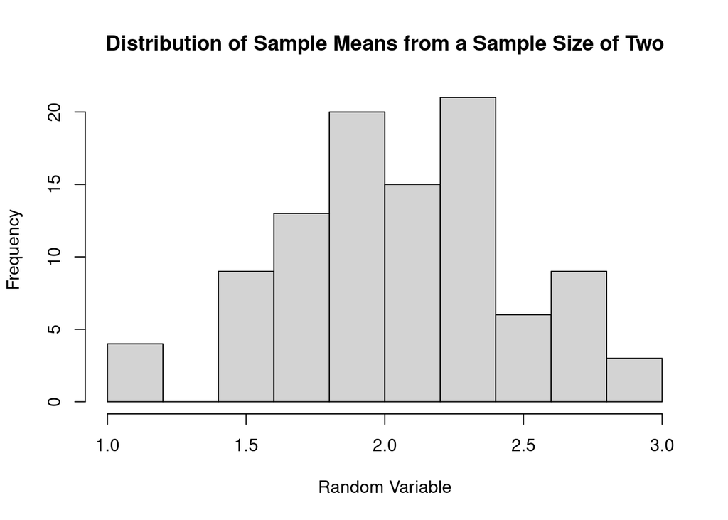

```r
set.seed(289) #set seed for reproducibility

#The random variable can take on 2 values (from 1-3)

#User defined function that generates random numbers and finds mean
sample.f = function(m)
{
  p <- mean(runif(m, min=1, max=3))
  return(p)
}


sample_1 = numeric(100)
for (i in 1:100)
{
  sample_1[i] = sample.f(2)
} #For loop that generates 2  values (from 1-3) finds mean then saves 100 times for 100 means

#sample_1
hist(sample_1, breaks = 10,
        main= "Distribution of Sample Means from a Sample Size of Two",
        xlab= "Random Variable")
```

### Sample Size of 10

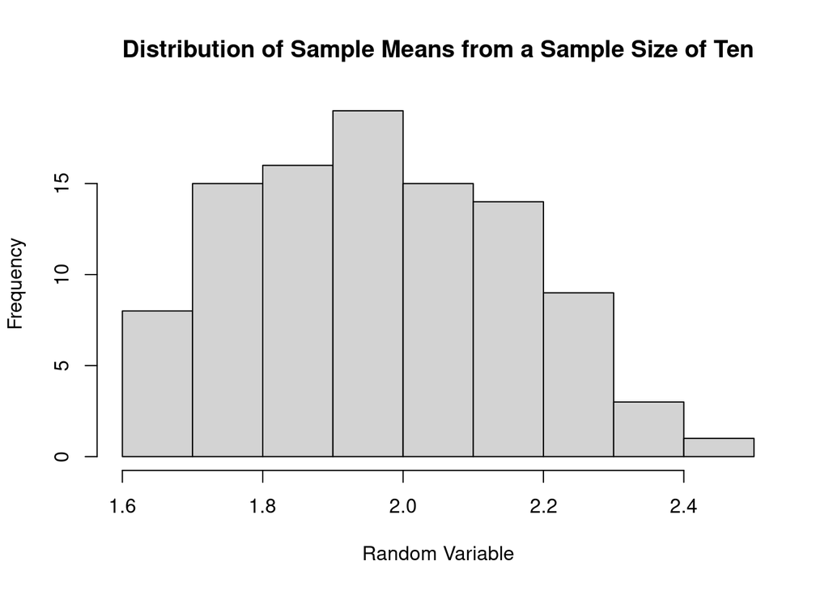

```r
sample_2 = numeric(100)
for (i in 1:100)
{
  sample_2[i] = sample.f(10)
}
#sample_2

hist(sample_2, breaks = 10,
        main= "Distribution of Sample Means from a Sample Size of Ten",
        xlab= "Random Variable")
```

### Sample Size of 50

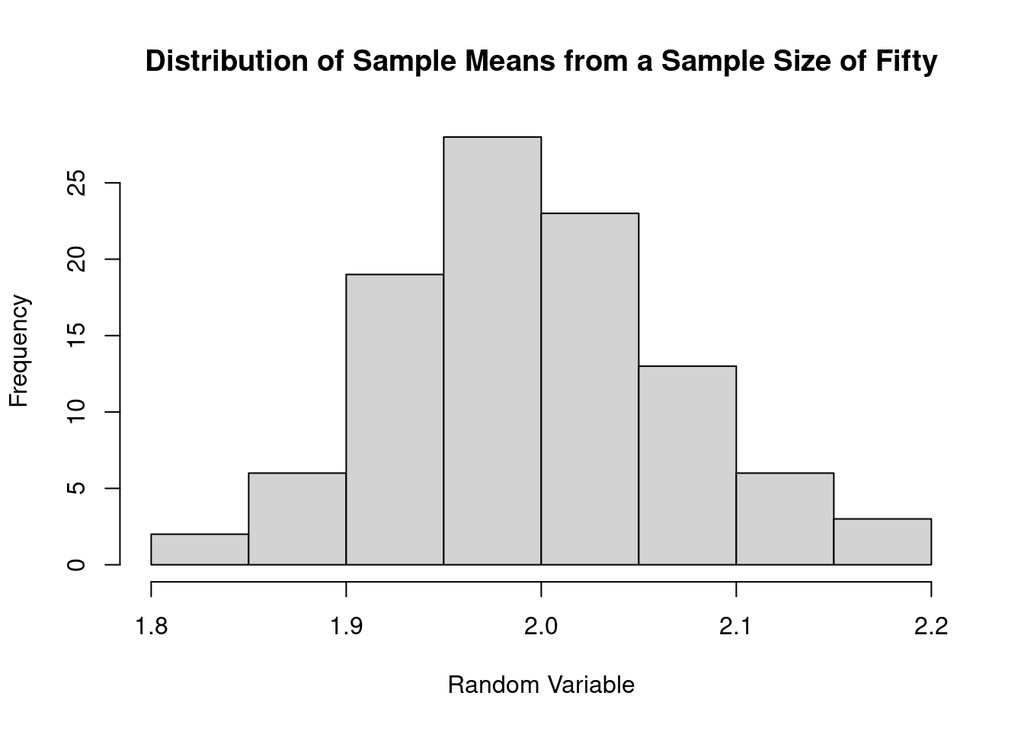

```r
sample_3 = numeric(100)
for (i in 1:100)
{
  sample_3[i] = sample.f(50)
}
#sample_3

hist(sample_3, breaks = 10,
        main= "Distribution of Sample Means from a Sample Size of Fifty",
        xlab= "Random Variable")
```

# **Section 2: Data Set Introduction**

The [Infectious Diseases by Disease, County, Year, and Sex Dataset](https://catalog.data.gov/dataset/infectious-diseases-by-disease-county-year-and-sex-6e856) published by The California Department of Public Health is to refer as `infect_data` in this analysis. `infect_data` contains case counts for selected infectious diseases from different counties in California from 2001 through 2022.  
The data piqued my interest because it includes a wide range of infectious diseases. Some of which are food-borne illnesses. I also thought it was interesting that the cases are sorted by sex. When researching for this project, I found that [sex-specific virulence](https://www.ncbi.nlm.nih.gov/pmc/articles/PMC5159935/) has been theorized in many diseases, which was a new concept for me. I wanted to investigate if there are also epidemiological trends of infectious disease cases based on sex with or without a biological basis.

The variables in the dataset are as follows:

- `Disease`: The Diseases reported for each case count
- `County`: The county in which the case occurred when they were diagnosed and State-wide total.
- `Year`: Estimated onset date ranging from the date of first appearance of symptoms to the date reported to the California Department of Public Health.
- `Sex`: The patient’s sex as reported. Categories include as `Female` (including transgender women) and `Male` (including transgender men). `Total` includes the sum of `Male`, `Female` and “Other”. “Other” indicates people whose reported gender was other than `Male` or `Female`/missing.
- `Cases`: count of cases per disease meeting the surveillance case definition.
- `Population`: The estimated population size (rounded to the nearest integer) for each county, year, and sex.
- `Rate`: The number of cases per 100,000 inhabitants in the population ((Cases *100,000)/Population). “-” indicates rate of zero.
- `Lower_95_CI`: Lower bound of the 95% confidence interval of `Rate`
- `Upper_95_CI`: Upper bound of the 95% confidence interval of `Rate`
- `infection_rate`: Infection rate was created for this project to exclude characters in `Rate`. It was created using the same calculation ((Cases *100,000)/Population).
- `Transmission`: Mode of transmission categories were created for this project. (diseases that could also be considered water-borne were excluded from the `food_borne` level)

Some descriptions were provided by the full data dictionary available [here](https://catalog.data.gov/dataset/infectious-diseases-by-disease-county-year-and-sex-6e856).

# **Section 3: Analysis and Results**

## Q1. Across all diseases, which counties in California have the highest infectious disease rate from 2001-2022?

Across all diseases and years included in this data set, Kern County had the highest overall infection rate. It is interesting that this conclusion changes when we `filter` for food-borne illness. In that plot, San Francisco County has the highest average infection rate from 2001-2022.

### All Diseases

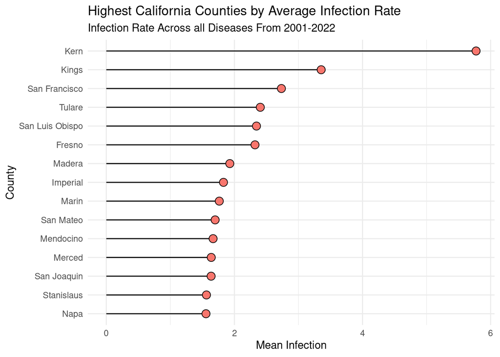

```r
infect_data_transmission |>
  filter(Sex == "Total",
         County != "California") |>
  group_by(County) |>
  summarize(mean_rate = mean(infection_rate)) |>
  arrange(-mean_rate) |>
  slice(1:15) |>
  ggplot() +
  aes(y= fct_reorder(County, mean_rate),
      x= mean_rate,
      fill="orange") +
  geom_segment(aes(x = 0,
                   xend = mean_rate,
                   y = fct_reorder(County, mean_rate),
                   yend = fct_reorder(County, mean_rate))) +
  geom_point(shape = 21,
             size = 3.5,
             show.legend=FALSE) +
  labs(x= "Mean Infection",
      y= "County",
      title= "Highest California Counties by Average Infection Rate",
      subtitle= "Infection Rate Across all Diseases From 2001-2022") -> q1_plot_1

q1_plot_1
```

```r
#colorblindr::cvd_grid(q1_plot_1)

ggsave(file.path(figure_path, "question_1_figure_1.png"),
       q1_plot_1,
       width=8, height=5)
```

### Food-Borne

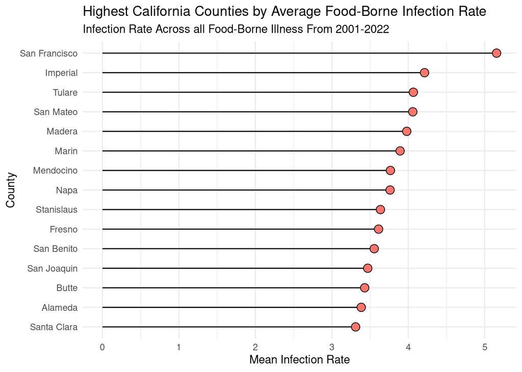

```r
infect_data_transmission |>
  filter(Sex == "Total",
         County != "California",
         Transmission=="foodborne") |>
  group_by(County) |>
  summarize(mean_rate = mean(infection_rate)) |>
  arrange(-mean_rate) |>
  slice(1:15) |>
  ggplot() +
  aes(y= fct_reorder(County, mean_rate),
      x= mean_rate,
      fill="orange") +
  geom_segment(aes(x = 0,
                   xend = mean_rate,
                   y = fct_reorder(County, mean_rate),
                   yend = fct_reorder(County, mean_rate))) +
  geom_point(shape = 21,
             size = 3.5,
             show.legend=FALSE) +
  labs(x= "Mean Infection Rate",
      y= "County",
      title= "Highest California Counties by Average Food-Borne Infection Rate",
      subtitle= "Infection Rate Across all Food-Borne Illness From 2001-2022") -> q1_plot_2

q1_plot_2
```

```r
#colorblindr::cvd_grid(q1_plot_2)

ggsave(file.path(figure_path, "question_1_figure_2.png"),
       q1_plot_2,
       width=8, height=5)
```

## Q2. In California, which years had the highest rate of food-borne illness infection?

California had the highest rate of food-borne illness infection in 2019. This is followed closely by 2018 and 2022. Interestingly, this plot also shows that the average infection rate of food-borne illness goes down dramatically in 2020.

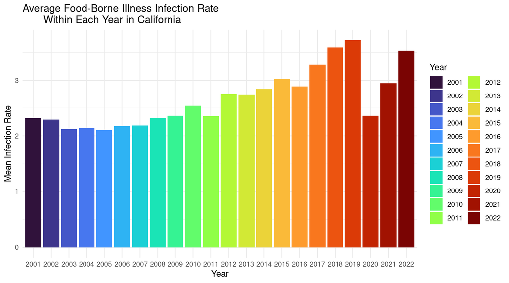

```r
infect_data_transmission_q2 <- infect_data_transmission
infect_data_transmission_q2$Year <- as.factor(infect_data_transmission$Year)

infect_data_transmission_q2 |>
  filter(Sex == "Total",
         County== "California",
         Transmission=="foodborne") |>
  group_by(Year) |>
  summarize(mean_rate = mean(infection_rate)) |>
  ggplot() +
  aes(x= Year,
      y= mean_rate) +
  geom_col(aes(fill=Year)) +
  labs(y= "Mean Infection Rate",
       x= "Year",
       title= "Average Food-Borne Illness Infection Rate
       Within Each Year in California ") +
  scale_fill_viridis_d(option = 'turbo') -> q2_plot

q2_plot
```

```r
#colorblindr::cvd_grid(q2_plot)

ggsave(file.path(figure_path, "question_2.png"),
       q2_plot,
       width=9, height=5)
```

Highest Average Infection Rate of Food-Borne Illness per 100,000 Inhabitants in California

| Year | Rate |
| --- | --- |
| 2019 | 3.7201 |
| 2018 | 3.5903 |
| 2022 | 3.5325 |
| 2017 | 3.2837 |
| 2015 | 3.0233 |
| 2021 | 2.9491 |
| 2016 | 2.8917 |
| 2014 | 2.8454 |
| 2012 | 2.7480 |
| 2013 | 2.7385 |
| 2010 | 2.5424 |
| 2009 | 2.3635 |
| 2020 | 2.3599 |
| 2011 | 2.3575 |
| 2008 | 2.3236 |

## Q3. In California, what is the correlation between population and average cases of infectious disease in a given year from 2001-2022?

From 2001-2022, there is a strong ($r=0.7796$) correlation between average cases in a given year and population overall in California. A correlation test found that around 61% of the variation in average cases in California from 2001-2022 can be explained by the linear regression model against population size ($r^2=0.6074$). This was found to have high level of significance ($p=2.0456*10^{-201})$). The average number of cases across all diseases went up around 5 cases for every 100,000 people in the population ($slope=5.6496*10^{-5}$). Here the decrease in average cases in 2020 is also shown.

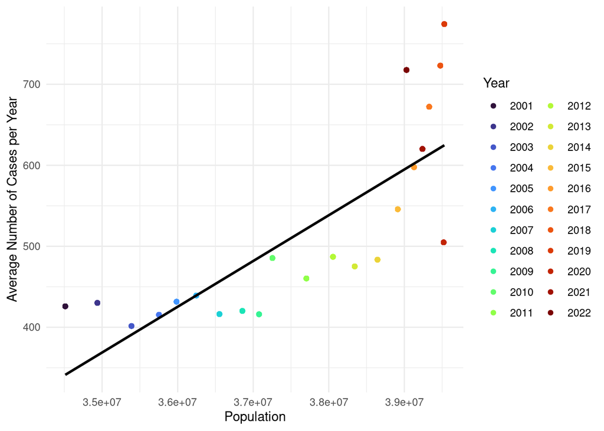

```r
## NEEDS CUSTOM COLORS AND CVDGRID ##
infect_data_transmission_q2 |>
  filter(Sex == "Total",
         County== "California") |>
  group_by(Year) |>
  mutate(mean_cases=mean(Cases)) |>
  ggplot(aes(y=mean_cases,
             x=Population)) +
  geom_point(aes(color=Year)) +
  geom_smooth(color= "black",
              method= 'lm', se= F) +
  labs(y= "Average Number of Cases per Year") +
  scale_color_viridis_d(option = 'turbo')-> q3_plot

q3_plot
```

```r
#colorblindr::cvd_grid(q3_plot)

ggsave(file.path(figure_path, "question_3.png"),
       q3_plot,
       width=8, height=5)

#infect_data_transmission |>
#  filter(Sex == "Total",
#         County== "California") |>
#  group_by(Year) |>
#  mutate(mean_cases=mean(Cases)) -> q3_point_data

#cor.test(q3_point_data$mean_cases,
#         q3_point_data$Population,
#        method = "pearson")

#model <- lm(formula = q3_point_data$mean_cases ~ q3_point_data$Population)

#model

#summary(model)
```

Population and Average Case of Infectious Disease in California by Year

| Year | Population | Cases |
| --- | --- | --- |
| 2001 | 34512742 | 425.9286 |
| 2002 | 34938290 | 430.0952 |
| 2003 | 35388928 | 401.5952 |
| 2004 | 35752765 | 415.4524 |
| 2005 | 35985582 | 431.5714 |
| 2006 | 36246822 | 439.2619 |
| 2007 | 36552529 | 416.2558 |
| 2008 | 36856222 | 420.1628 |
| 2009 | 37077204 | 416.0698 |
| 2010 | 37253956 | 485.4884 |
| 2011 | 37703593 | 460.3111 |
| 2012 | 38055785 | 487.0000 |
| 2013 | 38342642 | 475.1778 |
| 2014 | 38644802 | 483.4444 |
| 2015 | 38913507 | 545.7333 |
| 2016 | 39127855 | 597.6667 |
| 2017 | 39328926 | 672.2708 |
| 2018 | 39476064 | 723.0833 |
| 2019 | 39529566 | 774.3125 |
| 2020 | 39520071 | 504.8542 |
| 2021 | 39239553 | 620.1875 |
| 2022 | 39028571 | 717.6250 |

## Q4. Does the correlation between population and average cases of infectious disease in a given year differ in different modes of transmission?

For vector borne disease, there is a weak correlation ($r=0.3674$) between average cases and population size. The model could only explain around 13% of the variation in average cases of vector borne illness ($p=1.369*10^{-7}$).  
For food borne disease, there was a very strong correlation ($r=0.8457$). The model could only explain around 72% of the variation in average cases of food borne illness ($p=2.021*10^{-79}$). On average, there was a case of food-borne illness for every 10,000 people in California from 2001-2022.  
All other diseases had a strong correlation ($r=0.6509$). 42% of the varation in average cases of all other disease were explained by the linear regression ($p=8.195*10^{-62}$). The slope of average cases of all other diseases as a function of population ($slope=5.7084*10^{-5}$) was also similar to the slope found in question 3 ($slope=5.6496*10^{-5}$). It is important the note that sample size was comparable in food-borne and vector-borne illness, but much larger for all other illness.

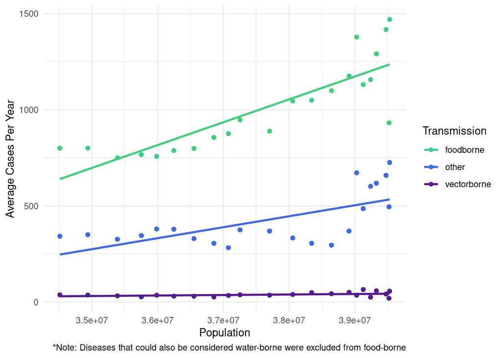

```r
infect_data_transmission |>
  filter(Sex == "Total",
         County== "California") |>
  group_by(Year, Transmission) |>
  mutate(mean_cases=mean(Cases)) |>
  ggplot(aes(y=mean_cases,
             x=Population,
             color= Transmission)) +
  geom_point() +
  geom_smooth(method= 'lm', se= F) +
  labs(y= "Average Cases Per Year",
       caption = "*Note: Diseases that could also be considered water-borne were excluded from food-borne") +
  scale_color_manual(name="Transmission",
                     values= c("seagreen3",
                               "royalblue",
                               "purple4")) -> q4_plot
q4_plot
```

```r
#colorblindr::cvd_grid(q4_plot)
ggsave(file.path(figure_path, "question_4.png"),
       q4_plot,
       width=8, height=5)

#infect_data_transmission |>
#  filter(Sex == "Total",
#         County== "California",
#         Transmission=="vectorborne") |>
#  group_by(Year) |>
#  mutate(mean_cases=mean(Cases)) -> q4_vector_data

## Correlation test for vector-borne disease ##
#cor.test(q4_vector_data$mean_cases,
#         q4_vector_data$Population,
#        method = "pearson")

#model_vector <- lm(formula = q4_vector_data$mean_cases ~ q4_vector_data$Population)
#summary(model_vector)

## Correlation test for food-borne disease ##
#infect_data_transmission |>
#  filter(Sex == "Total",
#         County== "California",
#         Transmission=="foodborne") |>
#  group_by(Year) |>
#  mutate(mean_cases=mean(Cases)) -> q4_food_data

#cor.test(q4_food_data$mean_cases,
#         q4_food_data$Population,
#        method = "pearson")

#model_food <- lm(formula = q4_food_data$mean_cases ~ q4_food_data$Population)
#summary(model_food)

## Correlation test for all other disease ##
#infect_data_transmission |>
#  filter(Sex == "Total",
#         County== "California",
#         Transmission=="other") |>
#  group_by(Year) |>
#  mutate(mean_cases=mean(Cases)) -> q4_other_data

#cor.test(q4_other_data$mean_cases,
#         q4_other_data$Population,
#        method = "pearson")

#model_other <- lm(formula = q4_other_data$mean_cases ~ q4_other_data$Population)
#summary(model_other)
```

## Q5. Are males or females more likely to get the most common diseases in Kern County?

### In Kern County

Statistical tests were performed on Coccidioidomycosis cases. Based on a chi-squared goodness of fit test, males are more likely to get Coccidioidomycosis in Kern County ($p<2.2*10{-16}$). A mixed model also found that sex is a good predictor of whether a person has Coccidioidomycosis ($p=0.002205$). Year was also found to be a good predictor for Coccidioidomycosis status in Kern County from 2001-2022 ($p=0.000578$). However, population was **not** found to be a good predictor in the model ($p=0.0608$).

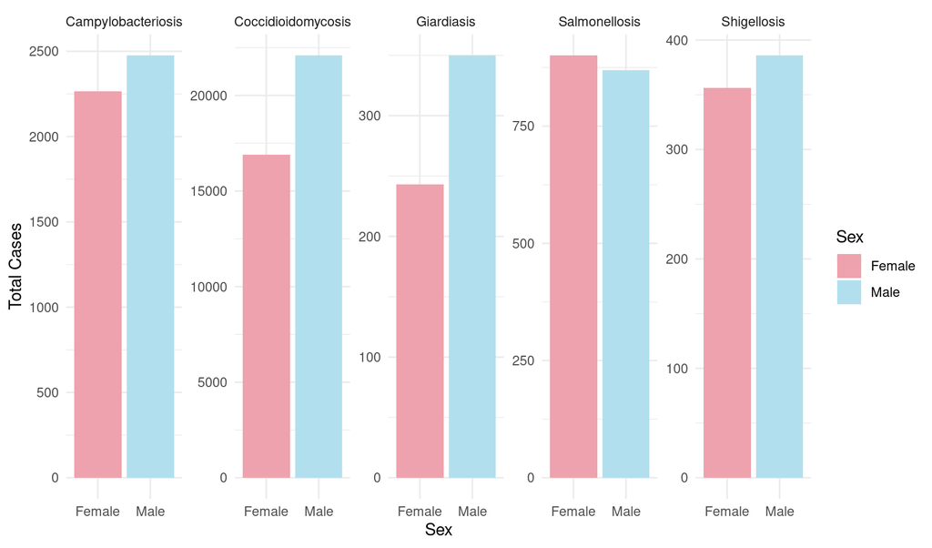

```r
infect_data |>
  filter(County == "Kern",
         Sex == "Total") |>
  group_by(Disease) |>
  summarize(total_cases = sum(Cases)) |>
  arrange(-total_cases) |>
  slice(1:5) |>
  ungroup() |>
  select(Disease) |>
  pull() -> top_disease_kern #Make a vector of the top diseases in Kern County.

infect_data |>
  filter(County == "Kern",
         Sex != "Total",
         Disease %in% top_disease_kern) |>
  group_by(Disease, Sex) |>
  summarize(total_cases = sum(Cases)) |>
  ungroup() -> q4_data  #Make a tibble of the total number of cases of those top diseases grouped by sex and disease in Kern.

q4_data|>
  ggplot(aes(y=total_cases,
             x=Sex,
             fill=Sex)) +
  geom_col() +
  facet_wrap(vars(Disease),
             nrow=1,
             scales="free") +
    scale_fill_manual(values= c("lightpink2",
                               "lightblue2")) +
  labs(y="Total Cases") -> q5_plot_1
q5_plot_1
```

```r
#colorblindr::cvd_grid(q5_plot_1)

ggsave(file.path(figure_path, "question_5_figure_1.png"),
       q5_plot_1,
       width=9.5, height=5)

## Chi-squared goodness-of-fit:  males vs. females ("Coccidioidomycosis")
#q4_data |>
#  filter(Disease=="Coccidioidomycosis") |>
#  select(total_cases) -> chi_squared_observed_Coccidioidomycosis

#null_probabilities <- c(1/2, 1/2)

#chisq.test(chi_squared_observed_Coccidioidomycosis,
#           p=null_probabilities) ## Reject the null. Men are more likely to be infected with "Coccidioidomycosis" in Kern County.

#infect_data |>
#  filter(County =="Kern",
#         Disease=="Coccidioidomycosis",
#         Sex != "Total") -> q5_model_data

#model <- lm(q5_model_data$Cases ~ #q5_model_data$Population+q5_model_data$Sex+q5_model_data$Year)

#summary(model)
```

### In California

Statistical tests were performed on Coccidioidomycosis cases. The findings in California were consistent with Kern County. Based on a chi-squared goodness of fit test, males are more likely to get Coccidioidomycosis in California ($p<2.2*10{-16}$). A mixed model also found that sex is a good predictor of whether a person has Coccidioidomycosis ($p=0.00447$). Year was also found to be a good predictor for Coccidioidomycosis status in California from 2001-2022 ($p=0.00332$). However, population was **not** found to be a good predictor in the model ($p=0.0881$).

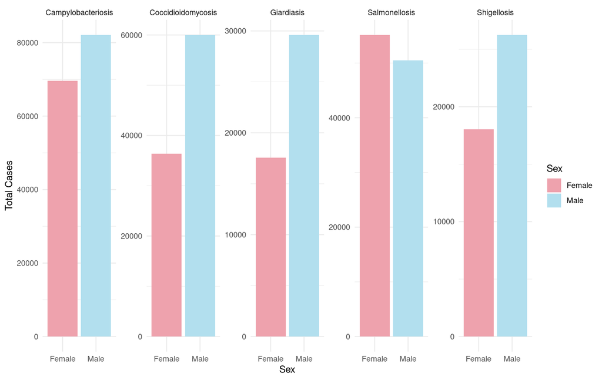

```r
## Overall in California
infect_data |>
  filter(Sex != "Total",
         County== "California",
         Disease %in% top_disease_kern) |>
  group_by(Disease, Sex) |>
  summarize(total_cases = sum(Cases)) |>
  ungroup() -> q5_1_data #Make a tibble of the total number of cases of those top diseases grouped by sex and disease in California.

q5_1_data|>
  ggplot(aes(y=total_cases,
             x=Sex,
             fill=Sex)) +
  geom_col() +
  facet_wrap(vars(Disease),
             nrow=1,
             scales="free") +
    scale_fill_manual(values= c("lightpink2",
                               "lightblue2")) +
  labs(y="Total Cases")-> q5_plot_2
q5_plot_2
```

```r
#colorblindr::cvd_grid(q5_plot_2)

ggsave(file.path(figure_path, "question_5_figure_2.png"),
       q5_plot_2,
       width=9.5, height=5)

## Chi-squared goodness-of-fit:  males vs. females ("Coccidioidomycosis")
#q5_1_data |>
#  filter(Disease=="Coccidioidomycosis") |>
#  select(total_cases) -> chi_squared_observed_Coccidioidomycosis


#chisq.test(chi_squared_observed_Coccidioidomycosis,
#           p=null_probabilities) ## Reject the null. Men are more likely to be infected with "Coccidioidomycosis" in California


#infect_data |>
#  filter(County =="California",
#         Disease=="Coccidioidomycosis",
#         Sex != "Total") -> q5_model_data_cali

#model <- lm(q5_model_data_cali$Cases ~ q5_model_data_cali$Population+q5_model_data_cali$Sex+q5_model_data_cali$Year)

#summary(model)
```